# Handling GPS data with Python

[figure not shown]

### Dr. Florian Wilhelm

#### Senior Data Scientist @ [inovex](http://www.inovex.de/)

# Motivation

- Project work and general interest
- Hard to find information about Python libraries
- Interest in the mathematical algorithms of that domain
- Needed a subject for a EuroPython talk ;-)

# GPX: GPS Exchange Format

- common GPS data format
- based on XML schema
- describes waypoints, routes and tracks
- GPS coordinates based GS-84 ellipsoid, height in meters

[figure not shown]

# General structure

```
<?xml version="1.0" encoding="UTF-8" standalone="no"?>
<gpx version="1.1" creator="Creator of the file">
  <metadata> <!-- metadata of the file --> </metadata>
  <wpt lat="xx.xxx" lon="yy.yyy"><!-- ... --></wpt>
  <!-- more waypoints -->
  <rte>
    <!-- attributes of the route -->
    <rtept lat="xx.xxx" lon="yy.yyy"><!-- ... --></rtept>
    <!-- more route points -->
  </rte>
  <!-- more routes -->
  <trk>
    <!-- attributes of the track -->
    <trkseg>
      <trkpt lat="xx.xxx" lon="yy.yyy"><!-- ... --></trkpt>
      <!-- more track points -->
    </trkseg>
    <!-- more track segments -->
  </trk>
  <!-- more tracks -->
</gpx>
```

# Example from Polar Flow

```
<?xml version="1.0" encoding="UTF-8"?>
<gpx xmlns="http://www.topografix.com/GPX/1/1" version="1.1" creator="Polar Flow">
  <metadata>
    <author>
      <name>Polar</name>
    </author>
    <time>2016-04-17T08:02:12.000Z</time>
  </metadata>
  <trk>
    <trkseg>
      <trkpt lat="53.560591" lon="9.9755985">
        <ele>17.0</ele>
        <time>2016-04-17T08:02:12.000Z</time>
      </trkpt>
      <trkpt lat="53.560591" lon="9.9755985">
        <ele>17.0</ele>
        <time>2016-04-17T08:02:13.000Z</time>
      </trkpt>
      <!-- ... many more points -->
    </trkseg>
  </trk>
</gpx>
```

# gpxpy: GPX file parser

- for reading and writing GPX files
- licensed unter Apache 2.0
- contains `gpxinfo` cli tool for basic stats
- Python 3 compatible
- written by Tomo Krajina
- used by http://www.trackprofiler.com/

```python
import gpxpy

with open('./gpx/hh_marathon.gpx') as fh:
    gpx_file = gpxpy.parse(fh)
```

```python
segment = gpx_file.tracks[0].segments[0]
coords = pd.DataFrame([
        {'lat': p.latitude,
         'lon': p.longitude,
         'ele': p.elevation,
         'time': p.time} for p in segment.points])
coords.set_index('time', drop=True, inplace=True)
coords.head(3)
```

| time | ele | lat | lon |
| --- | --- | --- | --- |
| 2016-04-17 08:02:12 | 17.0 | 53.560591 | 9.975599 |
| 2016-04-17 08:02:13 | 17.0 | 53.560591 | 9.975599 |
| 2016-04-17 08:02:14 | 17.0 | 53.560561 | 9.975591 |

# Plotting a track

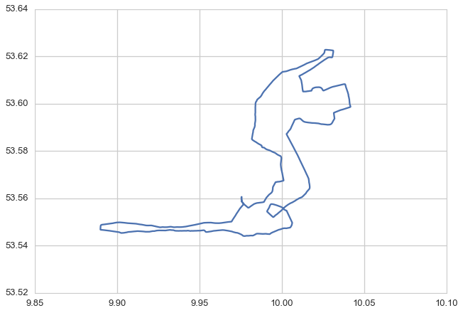

```python
plt.plot(coords['lon'].values, coords['lat'].values)
```

## ... and the actual GPS coordinates

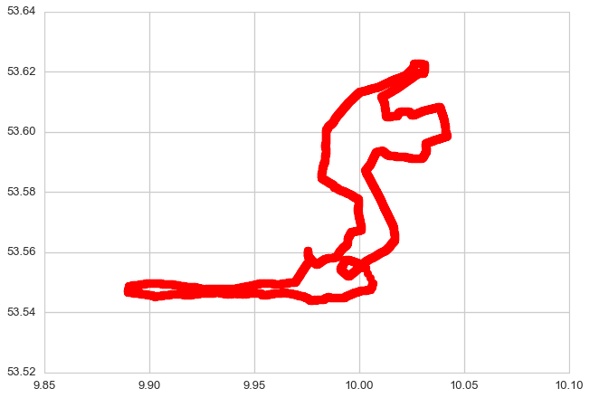

```python
plt.plot(coords['lon'].values, coords['lat'].values)
plt.plot(coords['lon'].values, coords['lat'].values, 'ro')
```

# Ohh! Need to reduce the number of points!

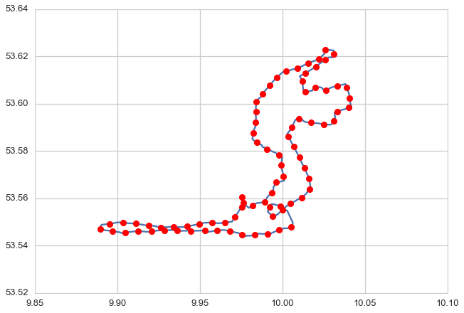

```python
plt.plot(coords['lon'].values, coords['lat'].values)
plt.plot(coords['lon'].values[::150], coords['lat'].values[::150], 'ro')
```

# Simplifying GPS tracks

Most GPS sensors have a uniform sampling rate leading to overly many points on almost straight lines.

## How can we reduce the number of points?

# Ramer-Douglas-Peucker algorithm

[figure not shown]

```
22632 points reduced to 806!
```

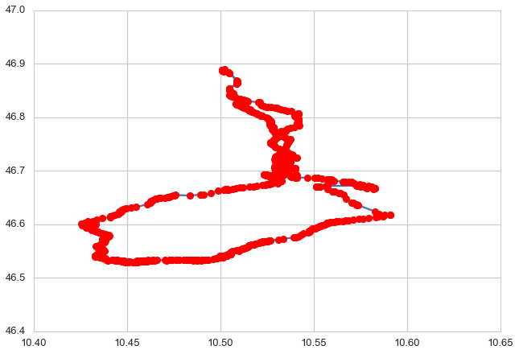

```python
simple_coords = rdp(coords[['lon', 'lat']].values, epsilon=1e-4)
print("{} points reduced to {}!".format(coords.shape[0], simple_coords.shape[0]))
plt.plot(simple_coords[:, 0], simple_coords[:, 1])
plt.plot(simple_coords[:, 0], simple_coords[:, 1], 'ro')
```

# Elevation of a GPS track

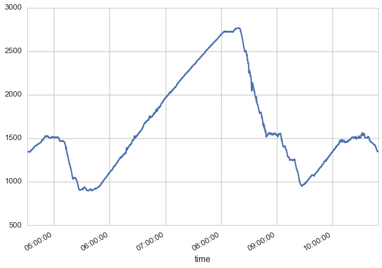

```python
coords.ele.plot()
```

## ... but what if the elevation was missing?

```python
# Delete elevation data
for p in gpx_file.tracks[0].segments[0].points:
    p.elevation = None
```

# srtm.py: add missing GPS elevation

- parser for the [Shuttle Radar Topography Mission elevation data](http://www2.jpl.nasa.gov/srtm/)
- extension for `gpxpy`
- licensed under Apache 2.0
- Python 3 compatible
- written by Tomo Krajina
- used by http://www.trackprofiler.com/

```python
import srtm
elevation_data = srtm.get_data()
elevation_data.add_elevations(gpx_file, smooth=True)
```

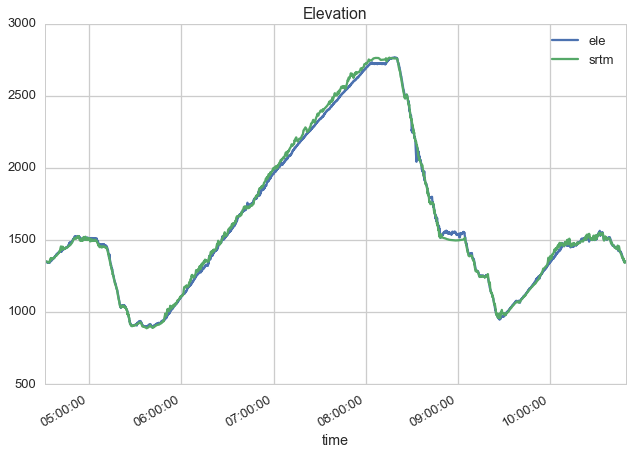

```python
coords['srtm'] = [p.elevation for p in gpx_file.tracks[0].segments[0].points]
coords[['ele','srtm']].plot(title='Elevation')
```

# mplleaflet: interactive Leaflet web maps

- converts a matplotlib plot into a pannable, zoomable slippy map
- extremely easy to use
- licensed under new-BSD
- integrates well with Jupyter
- Python 3 compatible
- tracks should be simplified with Ramer-Douglas-Peucker algorithm first

# First we start with a matplotlib plot...

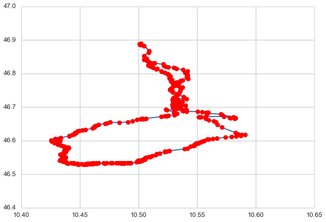

```python
fig = plt.figure()
plt.plot(simple_coords[:,0], simple_coords[:,1])
plt.plot(simple_coords[:,0], simple_coords[:,1], 'ro')
```

# ... and project it onto OpenStreetMap

```python
import mplleaflet
mplleaflet.display(fig=fig) # .show(fig=fig) to display in new window
```

[interactive chart not shown]

```python
mplleaflet.display(fig=fig)
```

[interactive chart not shown]

# Kalman Filter and Smoother

- *State equation*: $\mathbf{x}_{k}=\mathbf{F}_{k}\mathbf {x}_{k-1}+\mathbf{B}_{k}\mathbf{u}_{k}+\mathbf{w}_{k}$ where
  - $\mathbf{x}_{k}$ is the state vector at timestep $k$,
  - $\mathbf{u}_{k}$ is the control vector at timestep $k$,
  - $\mathbf{F}_{k}$ is the state transition matrix,
  - $\mathbf{B}_{k}$ is the control-input matrix,
  - $\mathbf{w}_{k}$ is the process noise $\mathbf{w}_{k}\sim{\mathcal{N}}(0,\mathbf{Q}_{k})$ with covariance $\mathbf{Q}_{k}$
- *Measurement equation*: $\mathbf{z}_{k}=\mathbf{H}_{k}\mathbf{x}_{k}+\mathbf{v}_{k}$ where
  - $\mathbf{z}_{k}$ is the measurement vector at timestep $k$,
  - $\mathbf{H}_{k}$ is the observation matrix,
  - $\mathbf{w}_{k}$ is the observation noise $\mathbf{v}_{k}\sim{\mathcal{N}}(0,\mathbf{R}_{k})$

# ... or much more intuitively put

Let

- $\mathbf{\hat{x}}_{k}^{-}$ be the *a priori* state estimate with knowledge about the process prior to $k$
- $\mathbf{\hat{x}}_{k}$ be the *a posteriori* state estimate including the the measurement $z_{k}$

and an update equation linking $\mathbf{\hat{x}}_{k}$ to $\mathbf{\hat{x}}_{k}^{-}$, i.e.

$$\mathbf{\hat{x}}_{k} = \mathbf{\hat{x}}_{k}^{-} + \mathbf{K}(\mathbf{\mathbf{z}_{k} - \mathbf{H}\hat{x}}_{k}^{-})$$

where $\mathbf{K}$ is the *Kalman gain*.

**Goal** is to find an optimal $\mathbf{K}$ that minimizes the *a posteriori* estimate error covariance $\mathbf{P}_{k} = \mathbb{E}[\mathbf{e}_k,\mathbf{e}_k]$ with $\mathbf{e}_{k}\equiv\mathbf{x}_{k}-\mathbf{\hat{x}}_{k}$.

[... read [An Introduction to the Kalman Filter](https://www.cs.unc.edu/~welch/media/pdf/kalman_intro.pdf) by G. Welch & G. Bishop for more details]

# ... and in practice

[figure not shown]

## Summary of libraries

- **gpxpy** for reading, writing GPX files as well as imputing of missing values.
- **srtm.py** extends gpxpy to easily add missing elevation data to a GPX file.
- **mplleaflet** converts matplotlib plots into zoomable, pannable, [Leaflet](http://leafletjs.com/) map.
- **rdp** implements the Ramer-Douglas-Peucker algorithm.
- **pykalman** is a dead-simple Kalman Filter, Smoother and EM library.

More notebooks with examples can be found under: https://github.com/FlorianWilhelm/gps_data_with_python/tree/master/notebooks

# Questions?

[figure not shown]

# Credits

- RDP Example from [Marius Karthaus](http://karthaus.nl/rdp/)
- Waypoint/track graphic adapted from [Wikipedia](https://en.wikipedia.org/wiki/GPS_Exchange_Format)
- Logo on first slide from [Gnome Maps](https://wiki.gnome.org/Apps/Maps)
- Kalman prediction & correction graphic from [Bilgin's blog](http://bilgin.esme.org/BitsAndBytes/KalmanFilterforDummies)
- Book [Kalman and Bayesian Filters](https://github.com/rlabbe/Kalman-and-Bayesian-Filters-in-Python) by Roger R. Labbe